# Data Science: Where in the World am I Going to Work?

Arthur Richardson

9/5/2022

# 1 **Dedication:**

This project is dedicated to my two daughters.

**Reflect on the important things to gain a better introspective and always move forward.**

**Love, Dad**.

# 2 **Introduction:**

I will analyze Data Science Job Salaries from Ruchi Bhatia. This data set contains salaries of jobs in the Data Science domain. The dataset variable terminology is located in the Data Science Job Salaries Data Set Glossary and Terminology Section of this document.

## 2.1 **Objective:**

Data Science is a diverse and rewarding career. In this project, we will explore the data associated with the career field of Data Science to give you an insight into the different job positions that are available to you based on Salary, Cost of Living, Position, Country, and more!

## 2.2 **Data Installation:**

Upload following packages and libraries for data exploration.

```r
library(tidyverse)
library(caret)
library(data.table)
library(RColorBrewer)
library(rmarkdown)
library(dslabs)
library(gtable)
library(hexbin)
library(gt)
library(dplyr)
library(ggpmisc)
library(gridExtra)
library(janitor)
library(lubridate)
library(highcharter)
library(viridisLite)
library(broom)
library(scales)
library(xfun)
library(htmltools)
library(mime)
library(ggfortify)
library(gtsummary)
library(tinytex)
library(vroom)
library(curl)
library(gtools)
library(hrbrthemes)
library(viridis)
library(latexpdf)
library(kableExtra)
library(showtext)
library(remotes)
library(extrafont)
```

## 2.3 **Data Analysis:**

Upload the data set. The file can be downloaded from https://www.kaggle.com/datasets/ruchi798/data-science-job-salaries

Download Salariesdataanalyst.zip

### 2.3.1 **Dimensions and Summary**

```
## [1] 607  12
```

The dataset has 607 observations for 12 variables.

#### 2.3.1.1 **Data Science Job Salaries Data Set Glossary and Terminology:**

1. Analyst ID: Provides an unique ID number to each Data Analyst Job.
2. Work Year: The year the salary was paid.
3. Experience Level: The experience level in the job during the year with the following possible values: EN Entry-level / Junior, MI Mid-level / Intermediate, SE Senior-level / Expert, EX Executive-level / Director.
4. Employment Type: The type of employement for the role: PT Part-time, FT Full-time, CT Contract, FL Freelance.
5. Job Title: The role worked in during the year.
6. Salary: The total gross salary amount paid.
7. Salary Currency: The currency of the salary paid as an ISO 4217 currency code.
8. Salary in USD; The salary in USD (FX rate divided by avg. USD rate for the respective year via fxdata.foorilla.com).
9. Employee Residence: Employee’s primary country of residence in during the work year as an ISO 3166 country code.
10. Remote Ratio: The overall amount of work done remotely, possible values are as follows: 0 No remote work (less than 20%), 50 Partially remote, 100 Fully remote (more than 80%).
11. Company Location: The country of the employer’s main office or contracting branch as an ISO 3166 country code.
12. Company_Size: The average number of people that worked for the company during the year: S means less than 50 employees (small). M means 50 to 250 employees (medium). L means more than 250 employees (large).

Based on all available positions in this dataset, lets get the average salary in USD. After, we will take a look at all jobs making less than and more than the average salary.

```
## [1] "$112,298"
```

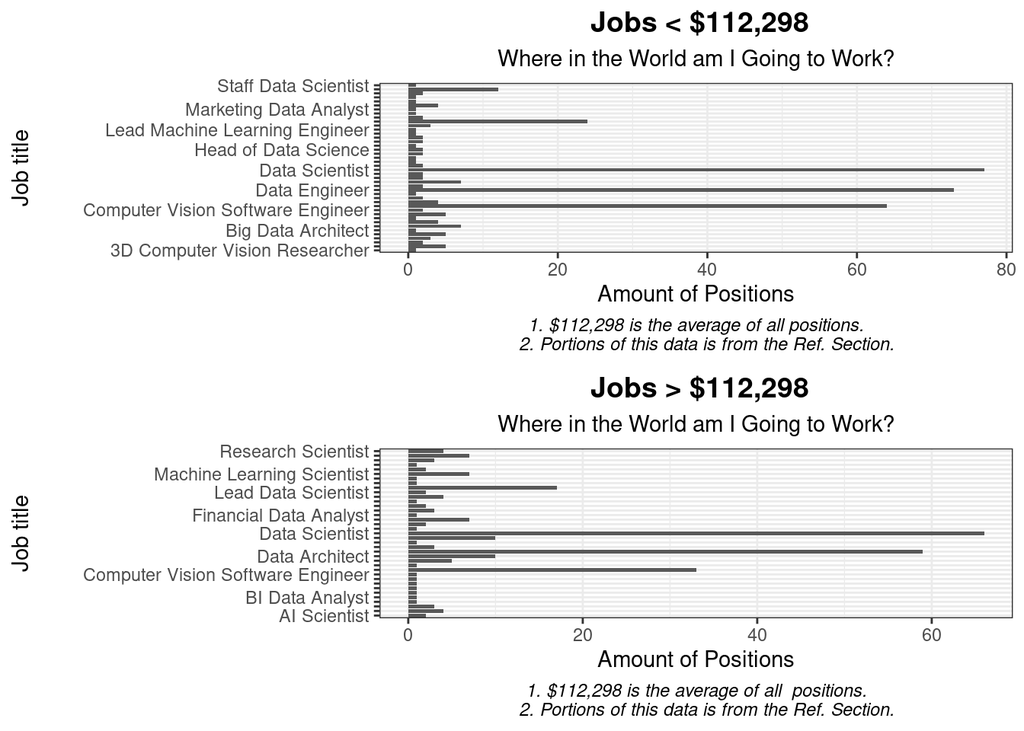

Now that we have an idea of the highest and lowest earners within the Data Science field, let’s take a look at the highest and lowest pay jobs.

**Highest Paying Job**

Data Analyst Jobs 2020-2022

| Job Title | Max. Salary | Exp. Level | Company Loc. | Company Size |
| --- | --- | --- | --- | --- |
| Principal Data Engineer | $600,000 | EX | US | L |

Portions of this data is from the Reference Section.  
Salary is in USD  
EX = Experience level is Executive-level  
US = United States  
L = Large Company, more than 250 employees

**Least Paying Job**

Data Analyst Jobs 2020-2022

| Job Title | Min. Salary | Exp. Level | Company Loc. | Company Size |
| --- | --- | --- | --- | --- |
| Data Scientist | $2,859 | MI | MX | S |

Portions of this data is from the Reference Section.  
Salary is in USD.  
MI = Experience level is Mid-Level  
MX = Mexico  
S = Small Company, less than 50 employees

After reviewing the highest and lowest-paying jobs, we have to factor in the cost of living. Per World Population Review (2022), “Mexico’s general minimum wage (Salario Minimo) was raised on January 1, 2022, to 172.87 pesos per work day, a 23% rise on the 2021 level of 141.70pesos. The rate for 2022 along the ‘Northern Border Zone’ was raised to 260.34 pesos per work day, a rise of 23% on the 2021 rate of 213.39 pesos. Mexico’s Minimum Wage Increased by 23% for 2022.” In USD, that’s about 8 dollars a day, which is $2920 a year. They are making below minimum wage and the cost of living is 491.91(USD) per month without rent factored into the equation!

As we can see, the cost of living can really affect if the salary is enough to support your lifestyle in a particular country.

Let us narrow down our specific job within the Data Science career field.

# 3 Career Exploration

As we explore the different jobs within the Data Science field, we need to know which positions are the most populated, which type of company would be more advantageous for us in regards to pay, and which country has the best career opportunities pay to fit your needs.

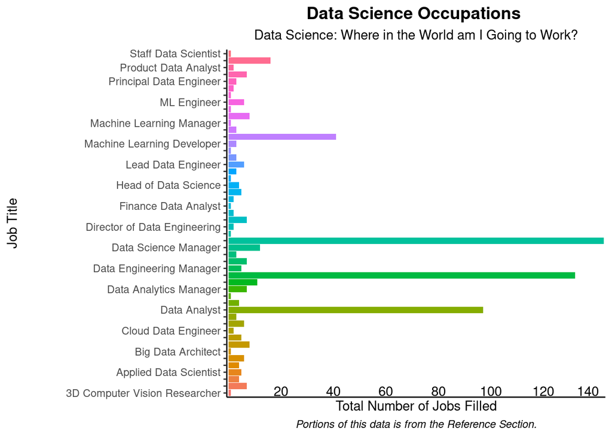

Take a look at the jobs with the most personnel.

```
## [1] "Data Scientist"
```

```
## [1] 143
```

Now lets evaluate the jobs with the least amount of personnel.

```
##  [1] "3D Computer Vision Researcher"  "Big Data Architect"
##  [3] "Data Analytics Lead"            "Data Specialist"
##  [5] "Finance Data Analyst"           "Head of Machine Learning"
##  [7] "Lead Machine Learning Engineer" "Machine Learning Manager"
##  [9] "Marketing Data Analyst"         "NLP Engineer"
## [11] "Staff Data Scientist"
```

```
## [1] 1
```

As you can see, the Data Science field has various positions. Data Scientist, Data Analyst, and Data Engineer are some of the most populated positions based on our data set. Next, we will visualize the countries with the largest, medium sized and smallest companies.

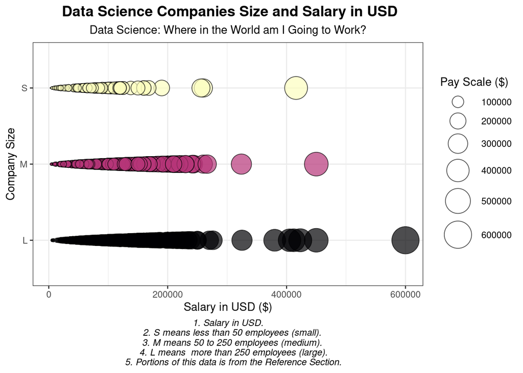

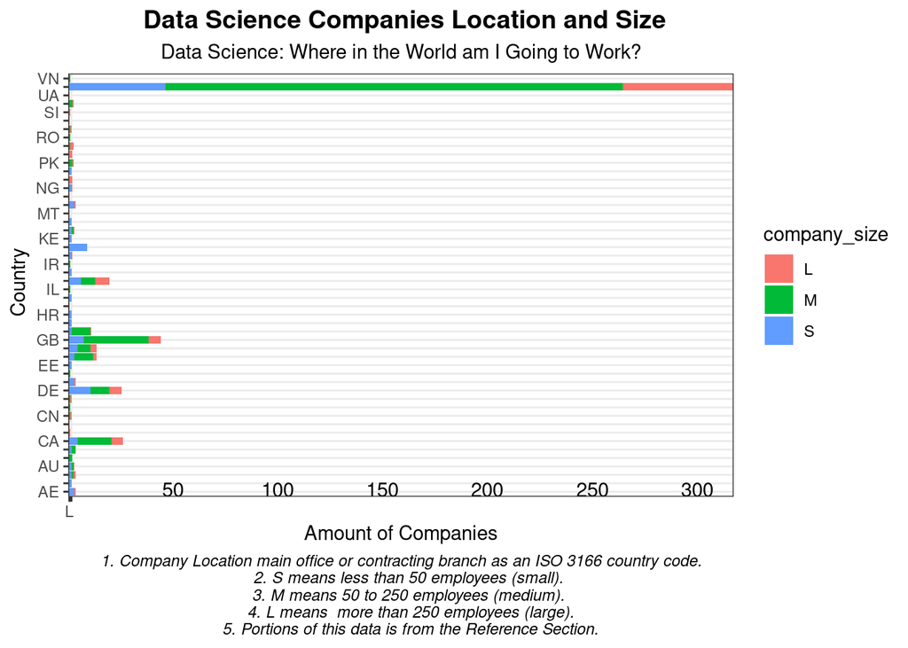

Since we have the Salary data, let’s explore which country has the ten highest-paying and lowest-paying jobs.

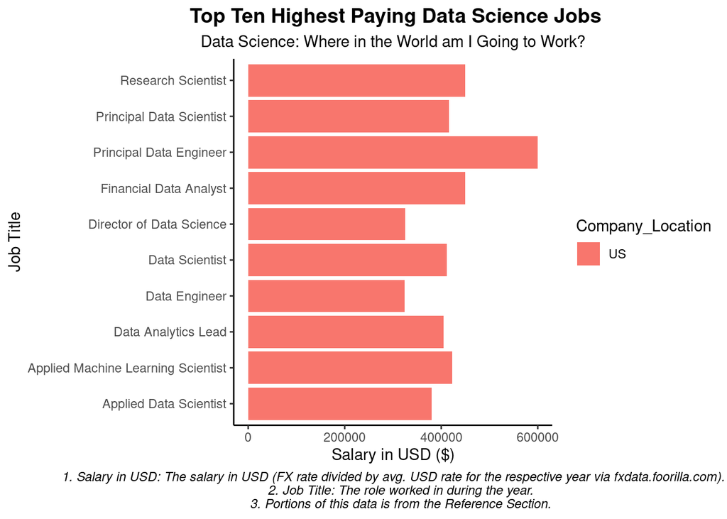

Now lets view the Bottom 10 positions by Salary.

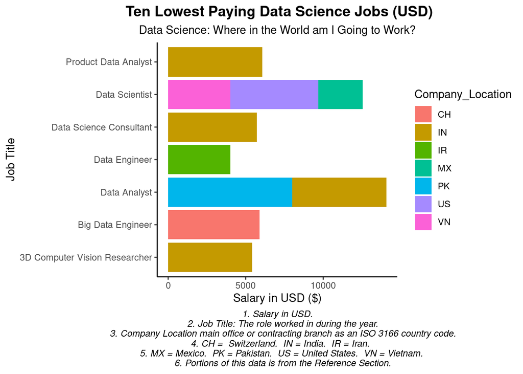

As we can see, the United States is the leader in the highest-paid positions. We know which jobs are the highest and lowest paying. Additionally, we know where they are located, but we all have different experience levels. Our experience level matters. You may be a novice analyst or sought-after expert within a specific field, but which job will pay you the most for your experience level? Let’s explore it.

[figure not shown]

Based on Experience, let us see which job pays the most and what country.

```
## # A tibble: 1 × 4
##   Title                     SalaryUSD Company_Location Exp
##   <chr>                         <dbl> <chr>            <chr>
## 1 Machine Learning Engineer    250000 US               EN
```

```
## # A tibble: 1 × 4
##   Title                  SalaryUSD Company_Location Exp
##   <chr>                      <dbl> <chr>            <chr>
## 1 Financial Data Analyst    450000 US               MI
```

```
## # A tibble: 1 × 4
##   Title          SalaryUSD Company_Location Exp
##   <chr>              <dbl> <chr>            <chr>
## 1 Data Scientist    412000 US               SE
```

```
## # A tibble: 1 × 4
##   Title                   SalaryUSD Company_Location Exp
##   <chr>                       <dbl> <chr>            <chr>
## 1 Principal Data Engineer    600000 US               EX
```

Now lets see if the benifits from Experience, Salary, and Location.

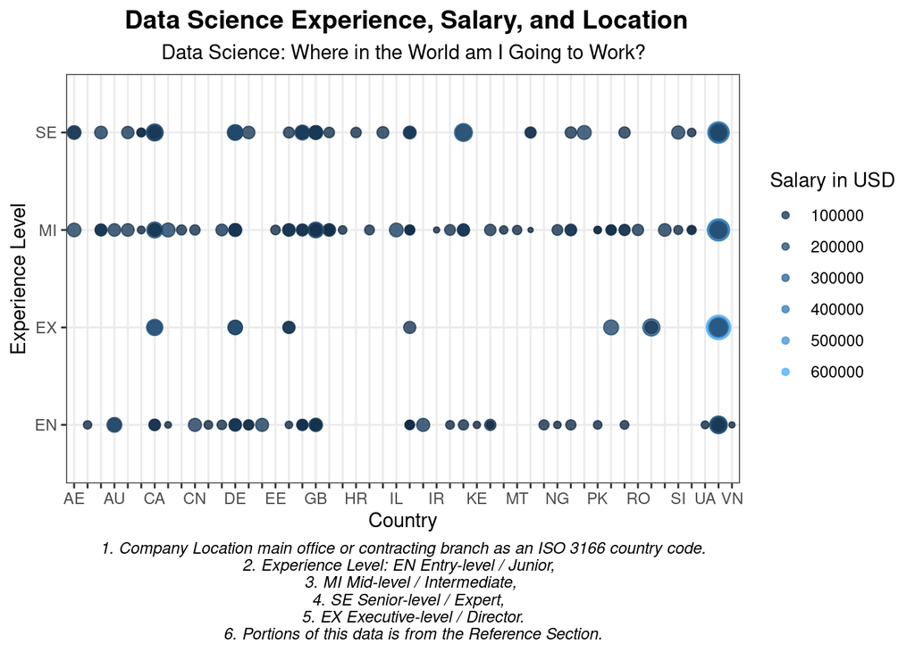

# 4 Career Location

Since February 11 2020, COVID-19 has changed the landscape of in person working experience. Most companies have transitioned to remote working. According to (J. Wise, 2022 ), “statistics indicate to us that around the world, 18% of people are now working remotely full-time. In America, over 4.3 million people work remotely, which is 3.2% of the workforce. Remote work is a growing trend, but 44% of companies currently do not let their employees work remotely.”

Per ApolloTechinical (“Apollo Technical LLC”, 2022), “Upwork estimates that 1 in 4 Americans, over 26% of the American workforce, will work remotely through 2021. They also estimate that 22% of the workforce (36.2 Million Americans) will work remotely by 2025.”

The remote worker for this dataset will be defined by remote ratio. The remote ratio for this dataset is the overall amount of work done remotely. Possible values are as follows: 0 No remote work (less than 20%), 50 Partially remote, 100 Fully remote (more than 80%). Let us explore the remote working opportunities within the data science field.

**Ten Best Remote Paying Jobs**

Data Analyst Jobs 2020-2022

Title

SalaryUSD

Company_Location

Exp

RemoteWork

Employee Residence

Year

Data Architect

266400

US

SE

100

US

2022

ML Engineer

270000

US

MI

100

US

2021

Data Engineer

324000

US

EX

100

US

2022

Director of Data Science

325000

US

EX

100

US

2020

Applied Data Scientist

380000

US

SE

100

US

2022

Data Analytics Lead

405000

US

SE

100

US

2022

Data Scientist

412000

US

SE

100

US

2020

Principal Data Scientist

416000

US

EX

100

US

2021

Financial Data Analyst

450000

US

MI

100

US

2021

Principal Data Engineer

600000

US

EX

100

US

2021

Portions of this data is from the Reference Section.

1. Salary is in USD.
2. Experience Level: The experience level in the job during the year with the following possible values: EN Entry-level / Junior, MI Mid-level / Intermediate, SE Senior-level / Expert, EX Executive-level / Director.
3. Employee Residence: Employee's primary country of residence in during the work year as an ISO 3166 country code.
4. Remote Ratio: The overall amount of work done remotely, possible values are as follows: 0 No remote work (less than 20%), 50 Partially remote, 100 Fully remote (more than 80%).

**Bottom Ten Remote Paying Jobs**

Data Analyst Jobs 2020-2022

Title

SalaryUSD

Company_Location

Exp

RemoteWork

Employee Residence

3D Computer Vision Researcher

5409

IN

MI

50

IN

Data Science Consultant

5707

IN

EN

50

IN

Data Analyst

8000

PK

MI

50

PK

Data Analyst

10354

ES

EN

50

ES

Machine Learning Scientist

12000

PK

MI

50

PK

Data Scientist

20171

TR

SE

50

TR

Data Engineer

21637

IN

EN

50

IN

Data Scientist

21669

IT

EN

50

IT

Machine Learning Engineer

21844

CO

EN

50

CO

Machine Learning Engineer

24823

SI

MI

50

SI

Portions of this data is from the Reference Section.

1. IN = India. PK = Pakistan. ES = Spain. TR = Turkey. IT = Italy. SI = Slovenia. CO = Columbia
2. Experience Level: The experience level in the job during the year with the following possible values: EN Entry-level / Junior, MI Mid-level / Intermediate, SE Senior-level / Expert, EX Executive-level / Director.
3. Employee Residence: Employee's primary country of residence in during the work year as an ISO 3166 country code.
4. Remote Ratio: The overall amount of work done remotely, possible values are as follows: 0 No remote work (less than 20%), 50 Partially remote, 100 Fully remote (more than 80%).

**Ten Best Non Remote Paying Jobs**

Data Analyst Jobs 2020-2022

Title

SalaryUSD

Company_Location

Exp

RemoteWork

Employee Residence

Research Scientist

450000

US

MI

0

US

Lead Data Engineer

276000

US

SE

0

US

Machine Learning Scientist

260000

JP

SE

0

JP

Director of Data Science

250000

US

EX

0

US

Data Science Manager

240000

US

SE

0

US

Data Engineer

220110

US

SE

0

US

Principal Data Scientist

220000

US

SE

0

US

Data Scientist

215300

US

SE

0

US

Data Engineer

206699

US

MI

0

US

Data Scientist

205300

US

SE

0

US

Portions of this data is from the Reference Section.

1. JP = Japan. US = United States.
2. Experience Level: The experience level in the job during the year with the following possible values: EN Entry-level / Junior, MI Mid-level / Intermediate, SE Senior-level / Expert, EX Executive-level / Director.
3. Employee Residence: Employee's primary country of residence in during the work year as an ISO 3166 country code.
4. Remote Ratio: The overall amount of work done remotely, possible values are as follows: 0 No remote work (less than 20%), 50 Partially remote, 100 Fully remote (more than 80%).

**Bottom Ten Non Remote Paying Jobs**

Data Analyst Jobs 2020-2022

Title

SalaryUSD

Company_Location

Exp

RemoteWork

Employee Residence

Data Scientist

2859

MX

MI

0

MX

Data Scientist

4000

VN

EN

0

VN

Big Data Engineer

5882

CH

EN

0

IN

Data Analyst

6072

IN

EN

0

IN

Data Scientist

9466

IN

MI

0

IN

Data Engineer

12103

TR

MI

0

TR

Data Scientist

12901

BR

MI

0

BR

Big Data Engineer

18000

MD

MI

0

MD

Computer Vision Engineer

18907

BR

SE

0

BR

Product Data Analyst

20000

HN

MI

0

HN

Portions of this data is from the Reference Section.

1. MX = Mexico. VN = Vietnam. CH = Switzerland. IN = India. TR = Turkey. BR = Brazil MD = Modolva HN = Honduras
2. Experience Level: The experience level in the job during the year with the following possible values: EN Entry-level / Junior, MI Mid-level / Intermediate, SE Senior-level / Expert, EX Executive-level / Director.
3. Employee Residence: Employee's primary country of residence in during the work year as an ISO 3166 country code.
4. Remote Ratio: The overall amount of work done remotely, possible values are as follows: 0 No remote work (less than 20%), 50 Partially remote, 100 Fully remote (more than 80%).

# 5 Conclusion

After exploring the different positions within the Data Science field, one may be able to make a sound decision on which position they would like to endeavor in, the country that provides them the most opportunities based on pay and experience level.

# 6 Reference Section:

1. Irizarry, R. A. (2022, July 7). Introduction to Data Science. HARVARD Data Science. Retrieved August 8, 2022, from Https://rafalab.github.io/dsbook/ This project utilized “Introduction to Data Science Data Analysis and Prediction Algorithms with R” by our course instructor Rafael A. Irizarry published 2022-07-07.
2. Cost of living. Cost of Living. (n.d.). Retrieved October 11, 2022, from https://www.numbeo.com/cost-of-living/ Numbeo is the world’s largest cost of living database. Numbeo is also a crowd-sourced global database of quality of life data: housing indicators, perceived crime rates, healthcare quality, transport quality, and other statistics.
3. Banton, C. (2022, February 8). Cost of living. Investopedia. Retrieved October 11, 2022, from https://www.investopedia.com/terms/c/cost-of-living.asp
4. Cost of living. Cambridge Dictionary. (n.d.). Retrieved October 11, 2022, from https://dictionary.cambridge.org/dictionary/english/cost-of-living
5. Cost of living index by state 2022. (n.d.). Retrieved October 11, 2022, from https://worldpopulationreview.com/state-rankings/cost-of-living-index-by-state
6. Wikimedia Foundation. (2022, October 5). List of ISO 3166 country codes. Wikipedia. Retrieved October 11, 2022, from https://en.wikipedia.org/wiki/List_of_ISO_3166_country_codes
7. Statistics on remote workers that will surprise you (2022). Apollo Technical LLC. (2022, May 31). Retrieved October 11, 2022, from https://www.apollotechnical.com/statistics-on-remote-workers
8. Wise, J. (2022, July 28). Remote work statistics 2022: How many people work from home during Covid? EarthWeb. Retrieved October 11, 2022, from https://earthweb.com/remote-work-statistics